# Clustering and Statistics

Matei Ionita

2023-02-06

## Data pooling

We begin by loading some packages, as well as the subsampled flowsets and manifest file created in the earlier pre-gating analysis.

```r
library(flowCore) # FCS files and cytometry specific data structures
library(tidyverse) # reading, wrangling and plotting tabular data
library(umap) # dimensional reduction
library(FlowSOM) # clustering
library(Rphenograph) # clustering
library(pheatmap) # pretty heatmaps
source("cluster_utils.R") # custom functions for labeling phenotypes

proj_base = ""
pic_base = paste0(proj_base, "results/young_old/pics/")

load(file = paste0(pic_base, "sampled_flowsets.rda"))

manifest <- read_csv(file = paste0(pic_base, "manifest.csv"))
manifest
```

```
## # A tibble: 136 × 7
##     ...1 FCS.File                     Age Age.Unit Gender Sample.Descrip…¹ valid
##    <dbl> <chr>                      <dbl> <chr>    <chr>  <chr>            <dbl>
##  1    69 Tphe09943-005-00_F4_R.fcs     76 Years    F      PBMC from Old d…     1
##  2     1 Tphe09943-005-07_F5_R.fcs     76 Years    F      PBMC from Old d…     1
##  3    70 Tphe09943-006-00_F7_R.fcs     67 Years    M      PBMC from Old d…     1
##  4     2 Tphe09943-006-07_F8_R.fcs     67 Years    M      PBMC from Old d…     1
##  5    71 Tphe09943-007-00_F10_R.fcs    62 Years    F      PBMC from Old d…     1
##  6     3 Tphe09943-007-07_F11_R.fcs    62 Years    F      PBMC from Old d…     1
##  7    72 Tphe09943-008-00_G1_R.fcs     28 Years    M      PBMC from Young…     1
##  8     4 Tphe09943-008-07_G2_R.fcs     28 Years    M      PBMC from Young…     1
##  9    73 Tphe09943-009-00_G4_R.fcs     33 Years    F      PBMC from Young…     1
## 10     5 Tphe09943-009-08_G5_R.fcs     33 Years    F      PBMC from Young…     1
## # … with 126 more rows, and abbreviated variable name ¹Sample.Description
```

`fs_gated` is a flowSet, containing a flowFrame for each biological sample. This is just a fancy way to say that we have a list of matrices with protein expression data. Indeed, we can use some standard list operations on flowSets, such as subsetting using `[]`. In this case, we want to select those instances which are valid according to our QC criteria.

```r
fs_gated <- fs_gated[which(manifest$valid==1)]

# the "apply" family of functions in base R is used to define a function
# on the fly, then apply it to each individual list item.
# fsApply does the same for flowSets
agg <- fsApply(fs_gated, function(ff) {
  # pattern match column names; | is "or" operator
  remove <- grep("FSC|SSC|Time|LIVE", colnames(ff))
  # extract expression data, without channels already used for pre-gating
  mat <- exprs(ff)[,-remove]
  return(mat)
})

dim(agg)
```

```
## [1] 1250000      15
```

Now we have a single matrix containing 10,000 cells from each of 125 files, and measurements of 15 proteins.

## Clustering: Dimensional Reduction

To build intuition, we begin our analysis with dimensional reduction, because this is a family of methods that lets us visualize the data.

Dimensional reduction methods are very time consuming, and running `umap` on a million cells would take a few hours. To save time, and since we’re using `umap` just as a visualization tool, we down-sample our data even more, to 20,000 total cells. To time the execution, we wrapped the call to `umap` inside a call to `system.time`. With as little as 20,000 cells, `umap` took 50s to run on Matei’s computer.

```r
set.seed(0) # set seed for reproducibility
sel <- sample(nrow(agg), 2e4)
data_sel <- agg[sel,] # subsample data
system.time(um <- umap(data_sel)) # run and time umap
```

```
##    user  system elapsed
##  50.786   0.939  51.747
```

For our first visualization, we run the simplest scatterplot of the two `umap` axes, using `ggplot`.

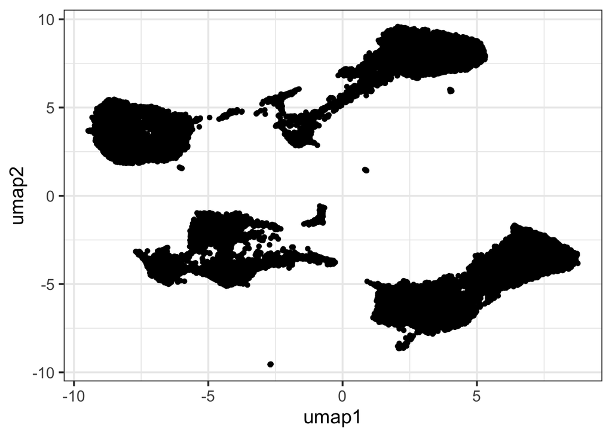

```r
# cast the subsampled data to a data frame
# mutate adds the 2 umap coordinates as new columns
dim_red <- as_tibble(data_sel) %>%
  mutate(umap1 = um$layout[,1],
         umap2 = um$layout[,2])

ggplot(dim_red, aes(x=umap1, y=umap2)) +
  geom_point() +
  theme_bw(base_size=16)
```

To make the plot more informative, we decrease the size and transparency of points, so that density becomes more apparent. We also color code the points by the expression of CD3, a protein which reliably marks T cells.

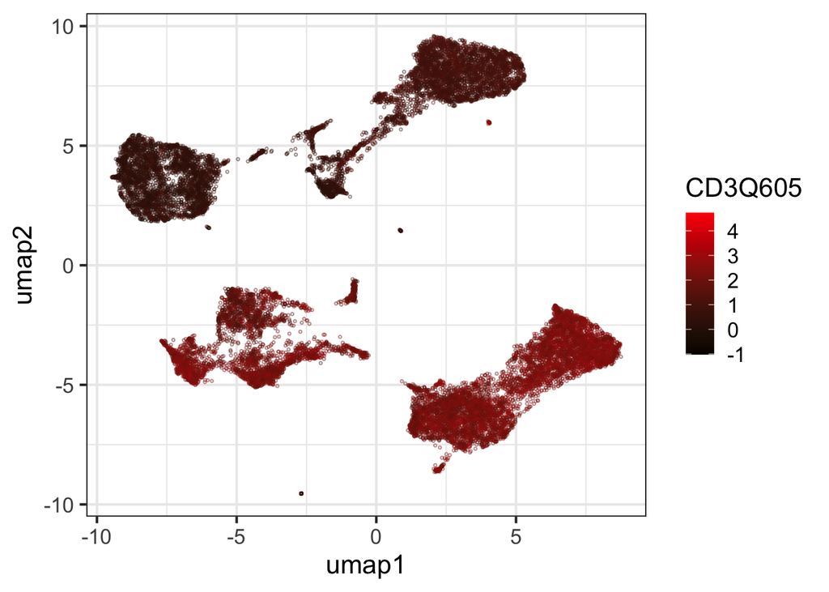

```r
ggplot(dim_red, aes(x=umap1, y=umap2, color=CD3Q605)) +
  geom_point(alpha=0.5, shape=1, size=0.5) +
  scale_color_gradient(low="black", high="red") +
  theme_bw(base_size=16)
```

We produce similar plots for all 15 proteins, and save them to file.

```r
for (marker in colnames(agg)) {
  # tidyverse makes it easy to write literal column names (umap1, umap2)
  # and annoying to use names stored in variables (marker)
  ggplot(dim_red, aes(x=umap1, y=umap2, color=.data[[marker]])) +
    geom_point(alpha=0.5, shape=1, size=0.5) +
    scale_color_gradient(low="black", high="red") +
    theme_bw(base_size=16)

  # ggsave has smart defaults for figure sizing
  ggsave(filename=paste0(pic_base, "umap/", marker, ".png"))
}
```

Recall that our goal is to count cells belonging to each phenotype, tabulate this information and use it in downstream statistical analysis. We could use the dimensionally reduced coordinates to define cell clusters, and assign each cell a cluster identity. However, we have two objections:

- A practical one: we only ran UMAP on 20,000 cells, and scaling it to all cells would take a long time.
- A philosophical one: most dimensional reduction algorithms are black boxes, which can distort data structure, or even create structure where there is none.

Instead, we will look at clustering algorithms that work directly with the 15-dimensional data, and scale linearly with the number of cells.

## Clustering: FlowSOM

FlowSOM is a fast and powerful algorithm, specialized for cytometry data. First, we run it with default settings; notice that it takes about 30s to process more than a million cells. The array `fsom_clustering` contains cluster membership ids for all cells; the function `table` can tell us how many there are of each type.

```r
set.seed(0)
system.time(fsom <- FlowSOM(agg)) # building the model
```

```
##    user  system elapsed
##  32.849   3.569  36.449
```

```r
fsom_clustering <- GetMetaclusters(fsom) # exctracting cluster ids
table(fsom_clustering)
```

```
## fsom_clustering
##      1      2      3      4      5      6      7      8      9     10
##   1117 249565 250984   1576 122093  76684 488694  53124   1180   4983
```

We can visualize the FlowSOM clustering results on the pre-existing UMAP embedding – just map the cluster ids to the color aesthetic in ggplot.

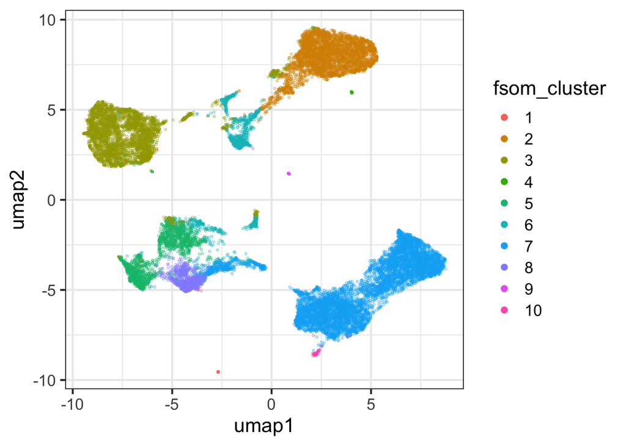

```r
# add cluster ids to the data frame,
# selecting only the 20,000 cells used by UMAP
dim_red <- dim_red %>%
  mutate(fsom_cluster = fsom_clustering[sel])

# technicality: the guides call overrides size/transparency settings,
# to make the legend more readable
ggplot(dim_red, aes(x=umap1, y=umap2, color=fsom_cluster)) +
  geom_point(alpha=0.5, shape=1, size=0.5) +
  guides(color = guide_legend(override.aes = list(alpha = 1, size = 2, shape=19))) +
  theme_bw(base_size=16)
```

FlowSOM produced 10 clusters, which don’t quite capture all the structure in the data – in particular, all CD4 T cells form a single cluster, regardless of memory or activation stage. How did it come up with 10? It turns out that this is a hard-coded default in the `FlowSOM` function, using the argument `nClus = 10`. To fix this, we could:

- Use the `maxMeta` argument, which overrides `nClus`, and looks for the optimum number of clusters up to `maxMeta`, using the elbow method. Unfortunately, their implementation tends to under-cluster a lot, so we don’t recommend using it.
- Try different values for `nClus`, and use either visual inspection or a criterion like elbow or silhouette to choose an optimal value.

It helps to separate the `FlowSOM` call into two separate steps: a call to `SOM` which does most of the work building the model, and one to `metaClustering_consensus` which only takes a second to do the final clustering. The latter step can be repeated with different values of `k`, at minimal computational overhead. Here, for simplicity, we run it only once with `k=25`.

```r
set.seed(0)
system.time(som <- SOM(agg)) # building the model
```

```
## Mapping data to SOM
```

```
##    user  system elapsed
##  17.819   0.135  17.966
```

```r
system.time(metacl <- metaClustering_consensus(som$codes, k=25)) # clustering
```

```
##    user  system elapsed
##   1.341   0.418   1.770
```

```r
fsom_clustering <- as.factor(metacl[som$mapping[,1]]) # extracting cluster ids
table(fsom_clustering)
```

```
## fsom_clustering
##      1      2      3      4      5      6      7      8      9     10     11
##   1117 222410 187868  26818   1576   5869  27155  47248   5023  17577  39012
##     12     13     14     15     16     17     18     19     20     21     22
##  14533   8166   7829  17202 224112  53124  46114   6032 227282   9724  37300
##     23     24     25
##  10746   1180   4983
```

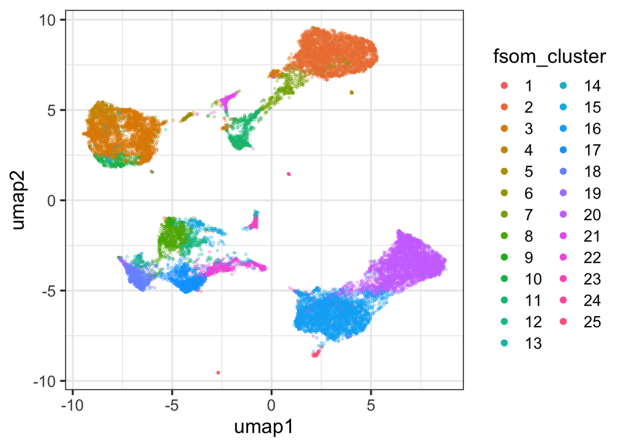

```r
dim_red <- dim_red %>%
  mutate(fsom_cluster = fsom_clustering[sel])

ggplot(dim_red, aes(x=umap1, y=umap2, color=fsom_cluster)) +
  geom_point(alpha=0.5, shape=1, size=0.5) +
  guides(color = guide_legend(override.aes = list(alpha = 1, size = 2, shape=19))) +
  theme_bw(base_size=16)
```

## Clustering: interpretation

Next, we should understand the phenotypes of the clusters that FlowSOM found. A first step is to compute a representative centroid for each cluster, and visualize the centroids on a heatmap.

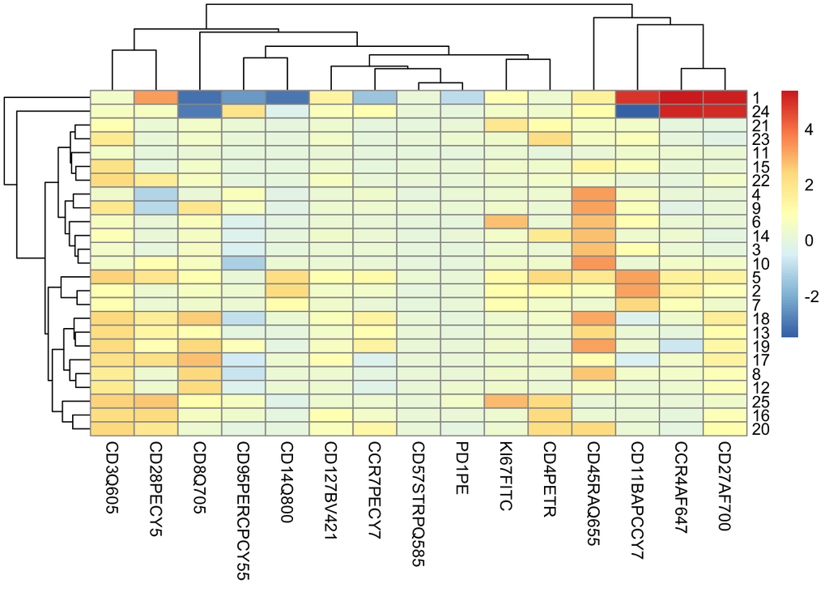

```r
fsom_medians <- sapply(levels(fsom_clustering), function(lev) {
  agg[which(fsom_clustering==lev),] %>% # selecting cells belonging to a cluster
    apply(2, median) # computing column-wise medians
}) %>% t()
pheatmap(fsom_medians) # pretty heatmaps
```

Clusters 1 and 24 turn out to be some sort of outliers, containing very few cells with unusually bright or dark expression for some markers. This is most likely a technical artifact, such as a compensation issue. We will ignore them downstream.

A second step is to label the clusters using human-readable phenotypes. This necessarily involves some domain knowledge, which we summarized in a data frame.

```r
defs <- read_csv("basic_phenos.csv")
defs
```

```
## # A tibble: 8 × 8
##   Phenotype              CD3Q605 CD4PETR CD8Q705 CD45R…¹ CCR7P…² CD14Q…³ KI67F…⁴
##   <chr>                  <chr>   <chr>   <chr>   <chr>   <chr>   <chr>   <chr>
## 1 T cell Other           hi      <NA>    <NA>    <NA>    <NA>    <NA>    <NA>
## 2 T cell CD4 Memory      hi      hi      <NA>    <NA>    <NA>    <NA>    <NA>
## 3 T cell CD4 Memory KI67 hi      hi      <NA>    <NA>    <NA>    <NA>    hi
## 4 T cell CD4 Naive       hi      hi      <NA>    hi      hi      <NA>    <NA>
## 5 T cell CD8 Memory      hi      lo      hi      <NA>    <NA>    <NA>    <NA>
## 6 T cell CD8 Memory KI67 hi      lo      hi      <NA>    <NA>    <NA>    hi
## 7 T cell CD8 Naive       hi      lo      hi      hi      hi      <NA>    <NA>
## 8 Monocyte               lo      <NA>    <NA>    <NA>    <NA>    hi      <NA>
## # … with abbreviated variable names ¹CD45RAQ655, ²CCR7PECY7, ³CD14Q800,
## #   ⁴KI67FITC
```

Using the centroids and the definitions, we can match each cluster to a phenotype, or label it “Other” if no match is found. We wrote a function called `label_clusters`, which splits each marker into “lo” and “hi” modalities, based on the distribution of the cluster centroids, and then matches them to definitions. Look in the `cluster_utils.R` file for details, although we stress that this implementation is imperfect, and we encourage you to build your own.

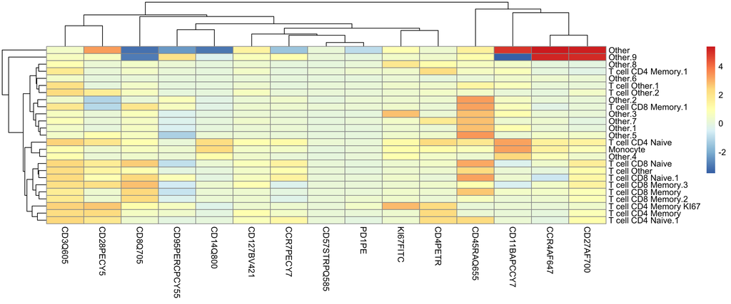

```r
# extract labels; ignore outlier clusters when defining modalities
labels <- label_clusters(fsom_medians, defs, outliers = c(1,24))
row.names(fsom_medians) <- labels
levels(fsom_clustering) <- labels

pheatmap(fsom_medians)
```

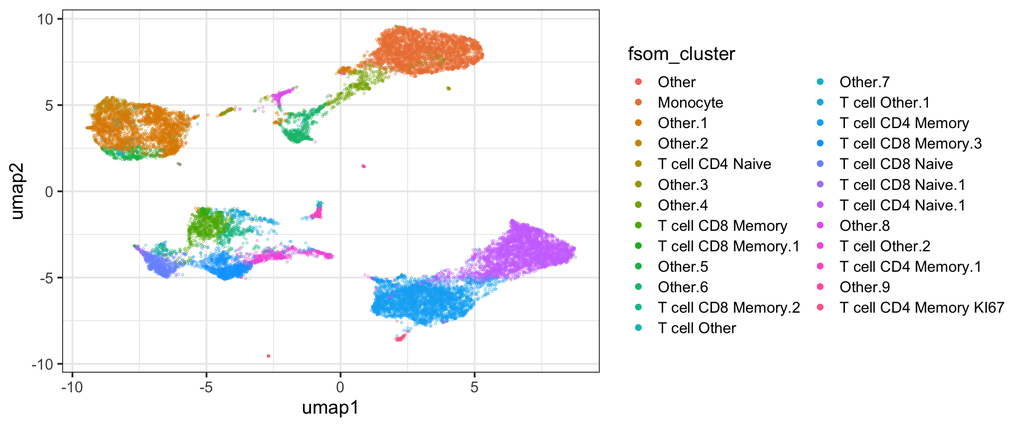

```r
dim_red <- dim_red %>%
  mutate(fsom_cluster = fsom_clustering[sel])

ggplot(dim_red, aes(x=umap1, y=umap2, color=fsom_cluster)) +
  geom_point(alpha=0.5, shape=1, size=0.5) +
  guides(color = guide_legend(override.aes = list(alpha = 1, size = 2, shape=19))) +
  theme_bw(base_size=16)
```

## Statistics

Now that we have a reasonable clustering, we look for associations of cluster sizes with sample metadata. We begin by tabulating cell type proportions in each file.

```r
n_each <- fsApply(fs_gated, nrow) %>% as.numeric() # how many cells in each file?
file_names <- manifest %>%
  filter(valid == 1) %>%
  pull(FCS.File) # what are the file names?
samples <- rep(file_names, times=n_each) # array with file id for each cell

tab <- table(samples, fsom_clustering) %>% # table of cluster counts by file
  apply(1, function(row) row/sum(row)) %>% # normalize counts to fractions
  t() # transpose, to have files along rows, clusters along columns

features <- as_tibble(tab) %>% # cast the table to a data frame
  mutate(FCS.File = row.names(tab)) %>% # add file names as a column
  relocate(FCS.File) # put the file names first

features
```

```
## # A tibble: 125 × 26
##    FCS.File        Other Monoc…¹ Other.1 Other.2 T cel…² Other.3 Other.4 T cel…³
##    <chr>           <dbl>   <dbl>   <dbl>   <dbl>   <dbl>   <dbl>   <dbl>   <dbl>
##  1 Tphe09943-005… 0.0003  0.152   0.106   0.0401  0.0006  0.0038  0.0158  0.0959
##  2 Tphe09943-005… 0.001   0.152   0.131   0.0429  0.0008  0.0033  0.0113  0.0876
##  3 Tphe09943-006… 0.0013  0.226   0.150   0.0248  0.001   0.0035  0.0234  0.0793
##  4 Tphe09943-006… 0.0011  0.268   0.119   0.0369  0.0008  0.002   0.0267  0.0628
##  5 Tphe09943-007… 0.0001  0.0738  0.0664  0.0036  0.0014  0.001   0.102   0.0357
##  6 Tphe09943-007… 0.0006  0.102   0.082   0.0136  0.001   0.0015  0.0604  0.0557
##  7 Tphe09943-008… 0.0006  0.113   0.168   0.0243  0.0005  0.0039  0.0191  0.0111
##  8 Tphe09943-008… 0.0002  0.127   0.157   0.0101  0.0007  0.0055  0.0248  0.0178
##  9 Tphe09943-009… 0.0007  0.192   0.182   0.0392  0.0013  0.0081  0.0094  0.0081
## 10 Tphe09943-009… 0.0015  0.201   0.190   0.0217  0.0014  0.0074  0.0148  0.0071
## # … with 115 more rows, 17 more variables: `T cell CD8 Memory.1` <dbl>,
## #   Other.5 <dbl>, Other.6 <dbl>, `T cell CD8 Memory.2` <dbl>,
## #   `T cell Other` <dbl>, Other.7 <dbl>, `T cell Other.1` <dbl>,
## #   `T cell CD4 Memory` <dbl>, `T cell CD8 Memory.3` <dbl>,
## #   `T cell CD8 Naive` <dbl>, `T cell CD8 Naive.1` <dbl>,
## #   `T cell CD4 Naive.1` <dbl>, Other.8 <dbl>, `T cell Other.2` <dbl>,
## #   `T cell CD4 Memory.1` <dbl>, Other.9 <dbl>, …
```

We put together the features with the sample metadata. The only interesting piece of metadata is age; following the authors who collected the data, we use a categorical “young”/“old” variable. As a warm-up exercise, let’s look at some boxplots of age distribution per group.

```r
# use a join to keep track of file order
# introduce a group variable as a shorthand for the clunky sample description
features_meta <- inner_join(manifest, features) %>%
  mutate(Group=if_else(grepl("Young", Sample.Description), "Young", "Old"))
```

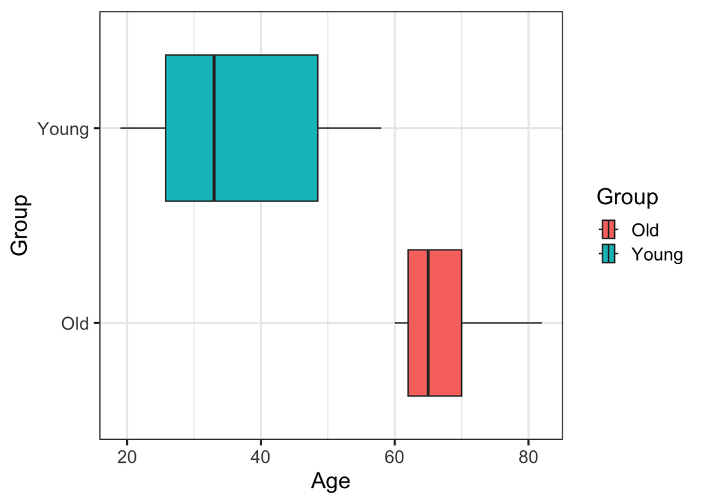

```r
ggplot(features_meta, aes(x=Age, y=Group, fill=Group)) +
  geom_boxplot() +
  theme_bw(base_size=16)
```

Replace the age with one of the cluster percentages we computed.

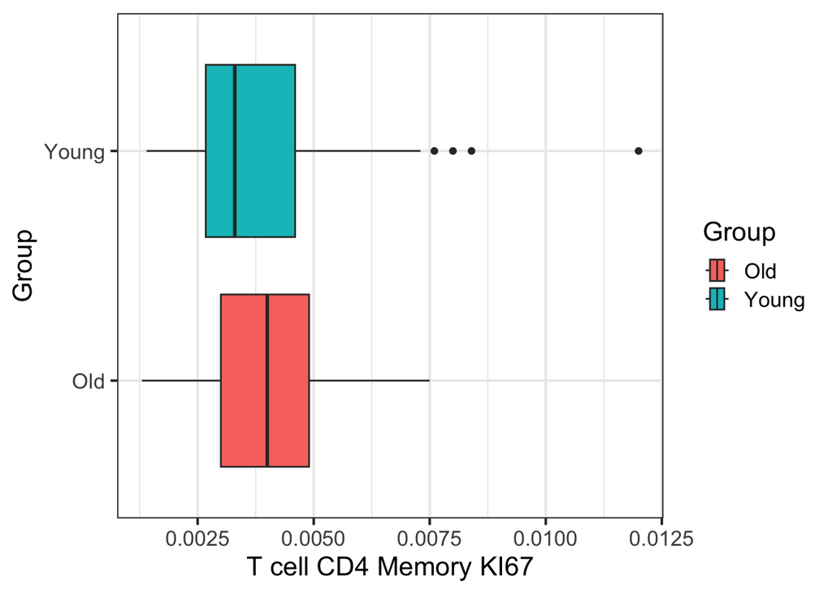

```r
ggplot(features_meta, aes(x=`T cell CD4 Memory KI67`,
                          y=Group, fill=Group)) +
  geom_boxplot() +
  theme_bw(base_size=16)
```

These are memory CD4 cells undergoing division. Usually this means they are activating in response to encountering an antigen, which makes them a meaningful feature in understanding immune responses. However, they don’t seem differentially expressed between our two age groups.

`ggplot` is great for multi-facet plots, which can show us the distribution of all clusters at once. First we pivot the data, then we plot:

```r
# pivot_longer turns the 25 columns of cluster frequencies into just two
# columns, one containing cluster names, the other the frequencies
features_meta_tall <- features_meta %>%
  pivot_longer(all_of(labels), names_to="cluster", values_to="frequency")
features_meta_tall
```

```
## # A tibble: 3,125 × 10
##     ...1 FCS.File         Age Age.U…¹ Gender Sampl…² valid Group cluster frequ…³
##    <dbl> <chr>          <dbl> <chr>   <chr>  <chr>   <dbl> <chr> <chr>     <dbl>
##  1    69 Tphe09943-005…    76 Years   F      PBMC f…     1 Old   Other    0.0003
##  2    69 Tphe09943-005…    76 Years   F      PBMC f…     1 Old   Monocy…  0.152
##  3    69 Tphe09943-005…    76 Years   F      PBMC f…     1 Old   Other.1  0.106
##  4    69 Tphe09943-005…    76 Years   F      PBMC f…     1 Old   Other.2  0.0401
##  5    69 Tphe09943-005…    76 Years   F      PBMC f…     1 Old   T cell…  0.0006
##  6    69 Tphe09943-005…    76 Years   F      PBMC f…     1 Old   Other.3  0.0038
##  7    69 Tphe09943-005…    76 Years   F      PBMC f…     1 Old   Other.4  0.0158
##  8    69 Tphe09943-005…    76 Years   F      PBMC f…     1 Old   T cell…  0.0959
##  9    69 Tphe09943-005…    76 Years   F      PBMC f…     1 Old   T cell…  0.0231
## 10    69 Tphe09943-005…    76 Years   F      PBMC f…     1 Old   Other.5  0.0123
## # … with 3,115 more rows, and abbreviated variable names ¹Age.Unit,
## #   ²Sample.Description, ³frequency
```

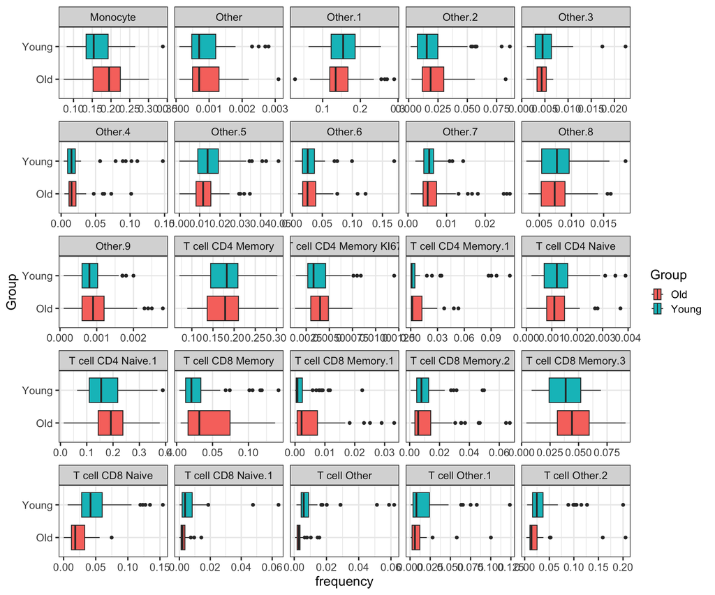

```r
# facet_wrap filters the tall data on each of the cluster names,
# creating a separate facet for each
ggplot(features_meta_tall, aes(x=frequency, y=Group, fill=Group)) +
  geom_boxplot() +
  facet_wrap(~cluster, scales="free_x") +
  theme_bw(base_size=16)
```

Visually, some clusters look differentially expressed. For a quantitative measure, we use the non-parametric Wilcoxon rank-sum test to check associations between cluster percentages and age group.

```r
# iterate over cluster labels and store a p value for each
pvals <- sapply(labels, function(label) {
  # select frequencies of current cluster in young group
  x <- features_meta %>%
    filter(Group=="Young") %>%
    pull(label)
  # select frequencies of current cluster in old group
  y <- features_meta %>%
    filter(Group=="Old") %>%
    pull(label)
  # run test
  wilcox <- wilcox.test(x,y)
  return(wilcox$p.value)
})

# adjust for multiple comparisons
padj <- p.adjust(pvals, method="fdr")
sort(padj)
```

```
##           T cell Other       T cell CD8 Naive         T cell Other.2
##           6.303664e-09           1.118798e-08           2.248051e-03
##    T cell CD8 Memory.1     T cell CD8 Naive.1               Monocyte
##           2.294114e-03           2.294114e-03           1.428591e-02
##      T cell CD8 Memory    T cell CD4 Memory.1    T cell CD8 Memory.3
##           4.602329e-02           7.957514e-02           1.276467e-01
##     T cell CD4 Naive.1         T cell Other.1                Other.5
##           1.276467e-01           1.360054e-01           1.528430e-01
##                Other.1                Other.2 T cell CD4 Memory KI67
##           3.778814e-01           3.840409e-01           4.579772e-01
##                Other.3                Other.9    T cell CD8 Memory.2
##           4.805105e-01           4.805105e-01           5.102004e-01
##                Other.8                Other.4       T cell CD4 Naive
##           6.134568e-01           7.188247e-01           7.577448e-01
##                Other.6                  Other      T cell CD4 Memory
##           7.584142e-01           8.289010e-01           8.584485e-01
##                Other.7
##           9.252139e-01
```

Success, we found some highly significant results! Let’s see the direction of these differences, by looking at boxplots for significant clusters only.

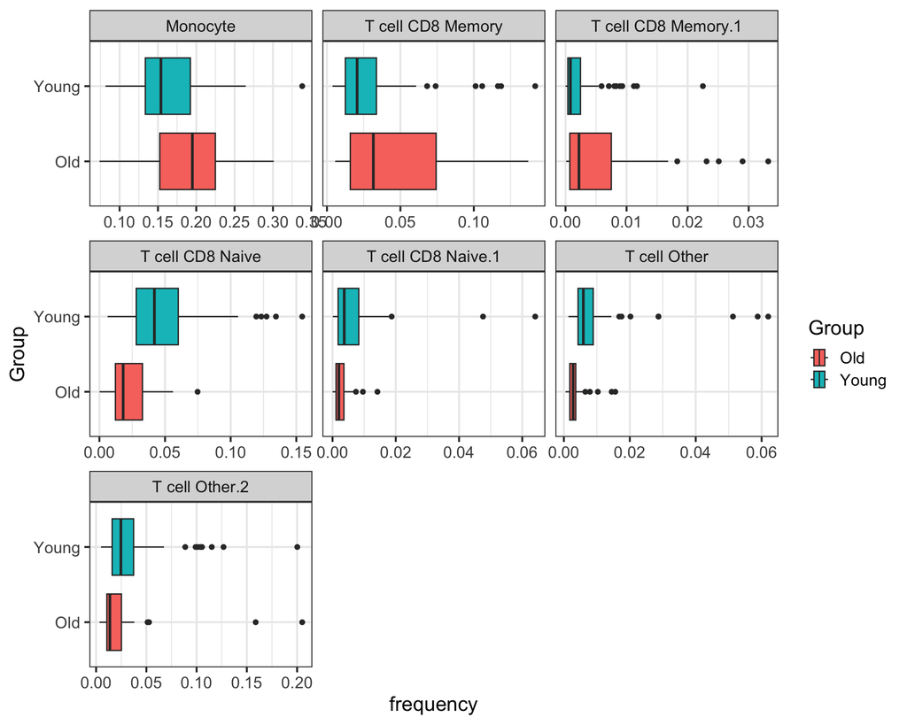

```r
# extract clusters which are significant at fdr < 5%
signif <- names(which(padj < 0.05))

# same as before, but filter on significant clusters
ggplot(features_meta_tall %>% filter(cluster %in% signif),
       aes(x=frequency,y=Group,fill=Group)) +
  geom_boxplot() +
  facet_wrap(~cluster, scales="free_x") +
  theme_bw(base_size=16)
```

Younger folks tend to have more naive T cells and fewer memory T cells. This is a known result which makes intuitive sense: young people have had fewer chances to encounter pathogens and build up an immune memory.